# ticket time analysis

Andrew Ba Tran

July 5, 2015

An analysis for the TrendCT story: [What time of day drivers get ticketed the most in Connecticut](http://trendct.org/2015/07/15/what-time-of-day-drivers-get-ticketed-the-most-in-connecticut)

The data is from the [Connecticut Racial Profiling Prohibition Project](http://ctrp3.ctdata.org/rawdata/) hosted at the [CT Data Collaborative](http://ctdata.org/) which collects traffic incident reports between October 2013 and September 2014.

```r
# Some libraries
library(lubridate)
library(ggplot2)

# Bringing the data in. This is a large file. Brace yourself.
#incidents <- read.csv("http://ctrp3viz.s3.amazonaws.com/data/Connecticut_r1.csv", stringsAsFactors=FALSE)


# Cleaning up the dates and time
incidents$RealDate <- as.POSIXct(as.Date(incidents$InterventionDateTime, origin="1899-12-30"))
incidents$RealTime <- format(as.POSIXct((incidents$InterventionTime) * 86400, origin = "1970-01-01"), "%H:%M")
incidents$RealTime <- hm(incidents$RealTime)
incidents$Hour <- hour(incidents$RealTime)
incidents$Hour2 <- hour(incidents$RealDate)
incidents$Day.of.Week <- as.factor(incidents$Day.of.Week)
levels(incidents$Day.of.Week) <- c("Sunday", "Monday", "Tuesday", "Wednesday", "Thursday", "Friday", "Saturday")
```

## What times do drivers get ticketed?

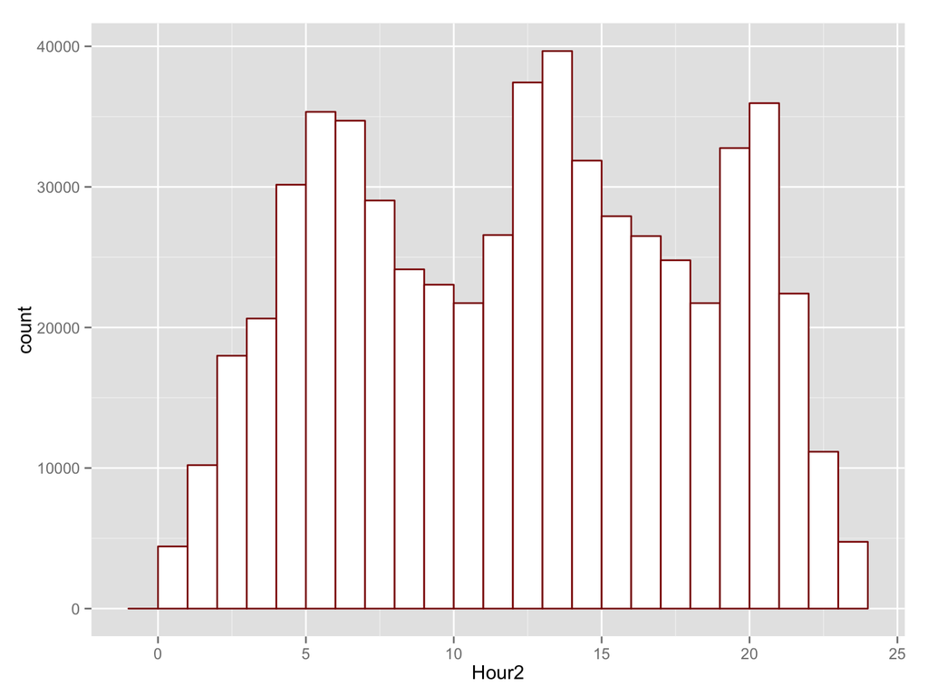

```r
c <- ggplot(incidents, aes(x=Hour2))
c <- c + geom_histogram(colour="darkred",fill="white", binwidth=1)
c
```

**Observations**

- Lunch time is most-frequent
- 2nd is post-dinner
- 3rd is right around the beginning of the morning rush hour

### Connecticut State Police hand out nearly 1/3 of all traffic tickets.

### Does the pattern change when their data is taken out?

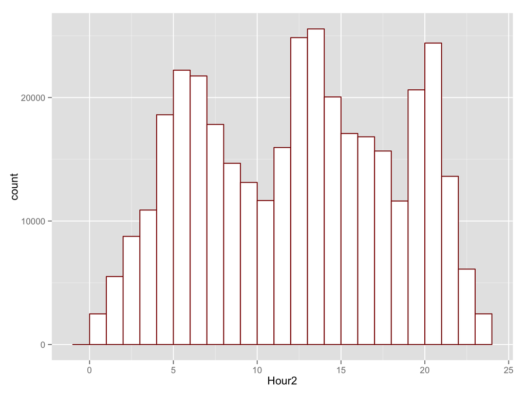

```r
no_state <- subset(incidents, Department.Name!="State Police")
c <- ggplot(no_state, aes(x=Hour2))
c <- c + geom_histogram(colour="darkred",fill="white", binwidth=1)
c
```

Answer: Nope. Looks about the samee as the chart above

## What time during each day of the week do tickets get assigned?

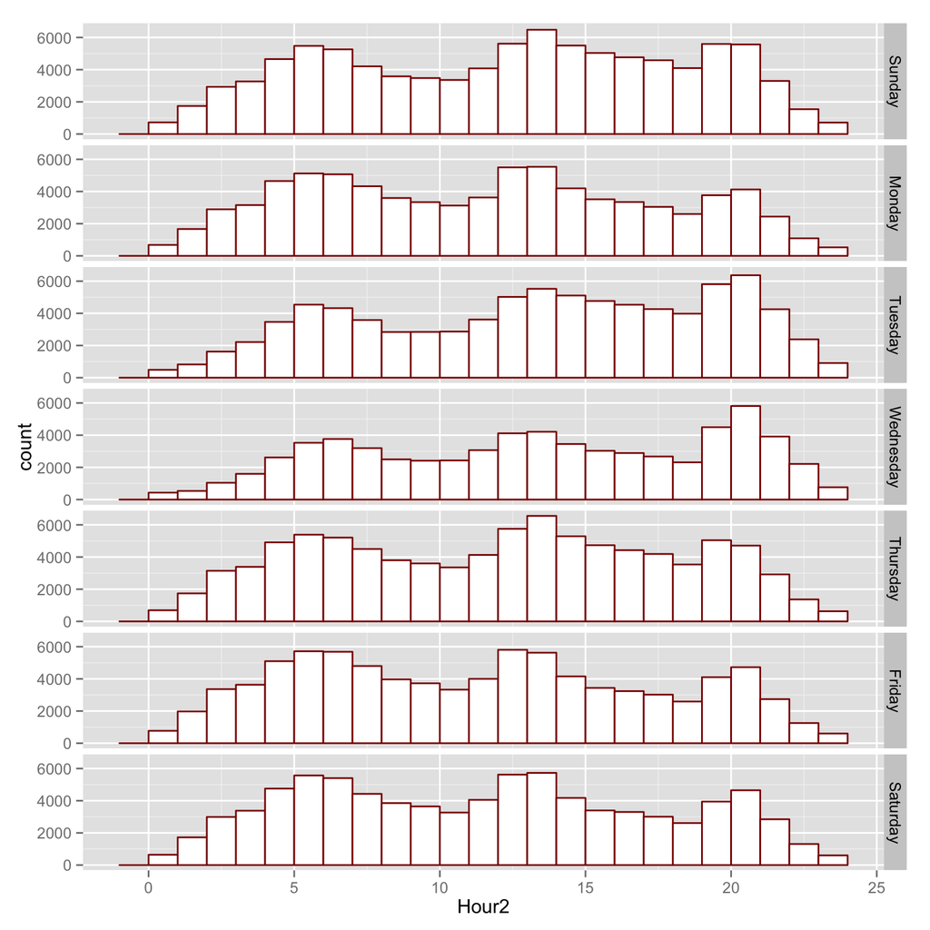

```r
c <- ggplot(incidents, aes(x=Hour2))
c <- c + geom_histogram(colour="darkred",fill="white", binwidth=1)
c + facet_grid(Day.of.Week ~ .)
```

**Observations**

- The last half of the week, more drivers tend to be ticketed more often in the mornings
- Tuesday and Wednesdays are weighted more toward the evenings
- The first of the half is pretty evenly split throughout the day

## Break it down by Department as a whole

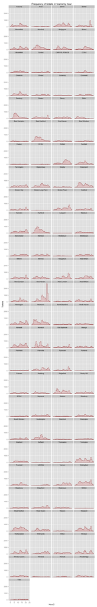

```r
# First, take out a few outliers
filtered <- subset(incidents, Department.Name!="State Police" & Department.Name!="MET DIST WATER AUTHORITY" & Department.Name!="MTA Stamford")

c <- ggplot(filtered, aes(x=Hour2))
c <- c + geom_histogram(colour="darkred",fill="white", binwidth=1)
c <- c + ggtitle("Frequency of tickets in towns by hour")
c <- c + ylab("Tickets")
department_histograms <- c + facet_wrap(~Department.Name, ncol=4)
department_histograms
```

**Observations**

- You probably don’t want to be driving around New Haven between 7 p.m. and 9 p.m.
- Suffield really goes after lunch time commuters
- The first of the half is pretty evenly split throughout the day

## Let’s take a look again with the y-scale relative to each town’s data

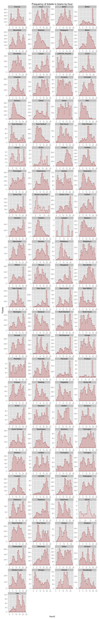

```r
filtered <- subset(incidents, Department.Name!="State Police" & Department.Name!="MET DIST WATER AUTHORITY" & Department.Name!="MTA Stamford")

c <- ggplot(filtered, aes(x=Hour2))
c <- c + geom_histogram(colour="darkred",fill="white", binwidth=1)
c <- c + ggtitle("Frequency of tickets in towns by hour")
c <- c + ylab("Tickets")
department_histograms <- c + facet_wrap(~Department.Name, ncol=4, scales="free")
department_histograms
```